# MethComp Data Sets

KevinOBrien

20 September 2018

`cardiac` : Measurement of cardiac output by two different methods.

### Description

For each subject cardiac output is measured repeatedly (three to six times) by impedance cardiography (IC) and radionuclide ventriculography (RV).

### Format

A data frame with 120 observations on the following 4 variables. * `meth` a factor with levels IC RV * `item` a numeric vector giving the item number. * `repl` a numeric vector with replicate number. * `y` the measuremnts of cardiac output.

```
##  meth         item            repl           y
##  IC:60   Min.   : 1.00   Min.   :1.0   Min.   :2.320
##  RV:60   1st Qu.: 3.75   1st Qu.:2.0   1st Qu.:4.200
##          Median : 6.50   Median :3.0   Median :4.805
##          Mean   : 6.60   Mean   :3.1   Mean   :5.023
##          3rd Qu.:10.00   3rd Qu.:4.0   3rd Qu.:6.055
##          Max.   :12.00   Max.   :6.0   Max.   :7.890
```

### Regression model of all measurements

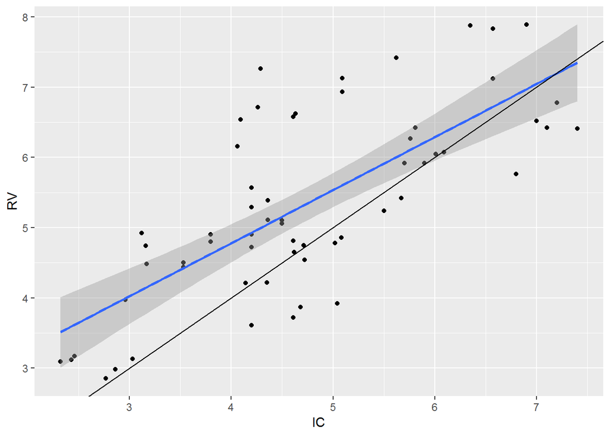

```r
cardiac  %>% spread(meth,y,fill=NA) %>%ggplot(aes(x=IC,y=RV)) +
  geom_point() +
  geom_smooth(method="lm") +
  geom_abline(intercept = 0,slope=1)
```

```r
cardiac.lm.1 <- cardiac  %>% spread(meth,y,fill=NA)
confint(lm(IC ~RV,data=cardiac.lm.1))
```

```
##                   2.5 %    97.5 %
## (Intercept) -0.01055787 1.8926608
## RV           0.53666844 0.8836102
```

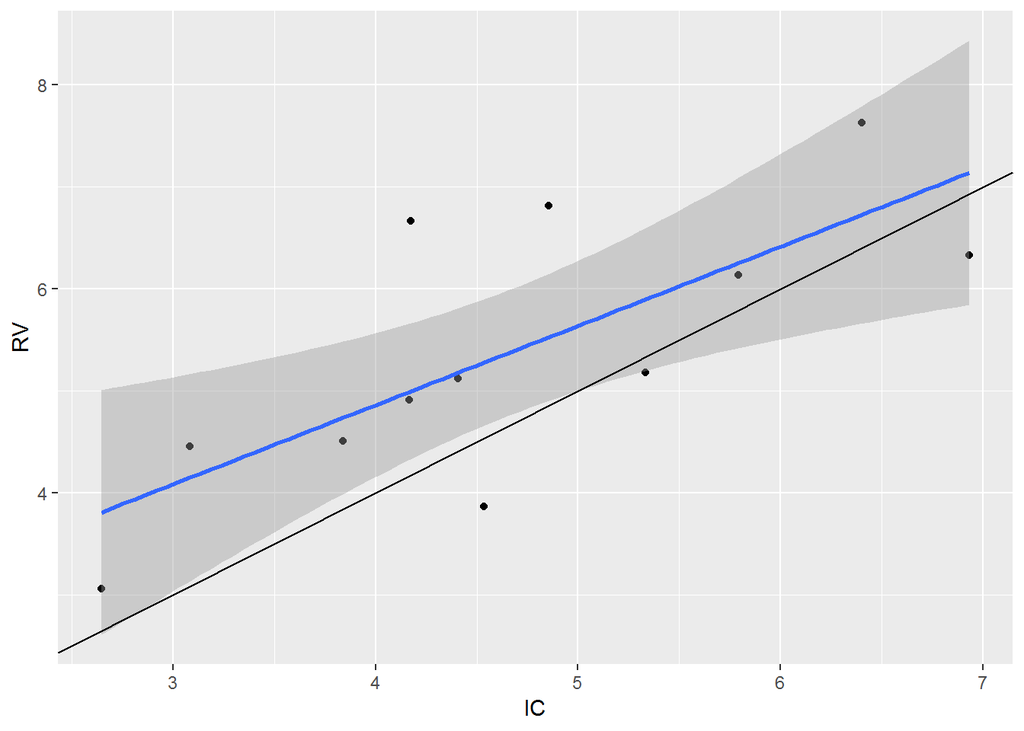

```r
cardiac.lm.2 <-cardiac %>% group_by(meth,item) %>% summarize(ybar =mean(y,na.rm=TRUE)) %>% spread(meth,ybar)
cardiac.lm.2 %>%ggplot(aes(x=IC,y=RV)) +
  geom_point() +
  geom_smooth(method="lm") +
  geom_abline(intercept = 0,slope=1)
```

```r
confint(lm(IC ~RV,data=cardiac.lm.2))
```

```
##                  2.5 %   97.5 %
## (Intercept) -1.5654902 3.446037
## RV           0.2417084 1.146172
```

```r
data(cardiac)
cardiac2 <- cardiac  %>% spread(repl,y,fill=NA) %>% set_colnames(c("meth","item","repl1","repl2","repl3","repl4","repl5","repl6"))
head(cardiac2)
```

```
##   meth item repl1 repl2 repl3 repl4 repl5 repl6
## 1   IC    1  6.57  5.62  6.90  6.57  6.35    NA
## 2   IC    2  4.06  4.29  4.26  4.09    NA    NA
## 3   IC    3  4.71  5.50  5.08  5.02  6.01  5.67
## 4   IC    4  4.14  4.20  4.61  4.68  5.04    NA
## 5   IC    5  3.03  2.86  2.77  2.46  2.32  2.43
## 6   IC    6  5.90  5.81  5.70  5.76    NA    NA
```

```
## The following variables from the dataframe
## "cardiac" are used as the Meth variables:
## meth: meth
## item: item
## repl: repl
##    y: y
##        #Replicates
## Method  3  4  5  6 #Items #Obs: 120 Values:  min   med  max
##     IC  1  3  3  5     12        60         2.32 4.610 7.40
##     RV  1  3  3  5     12        60         2.85 5.105 7.89
```

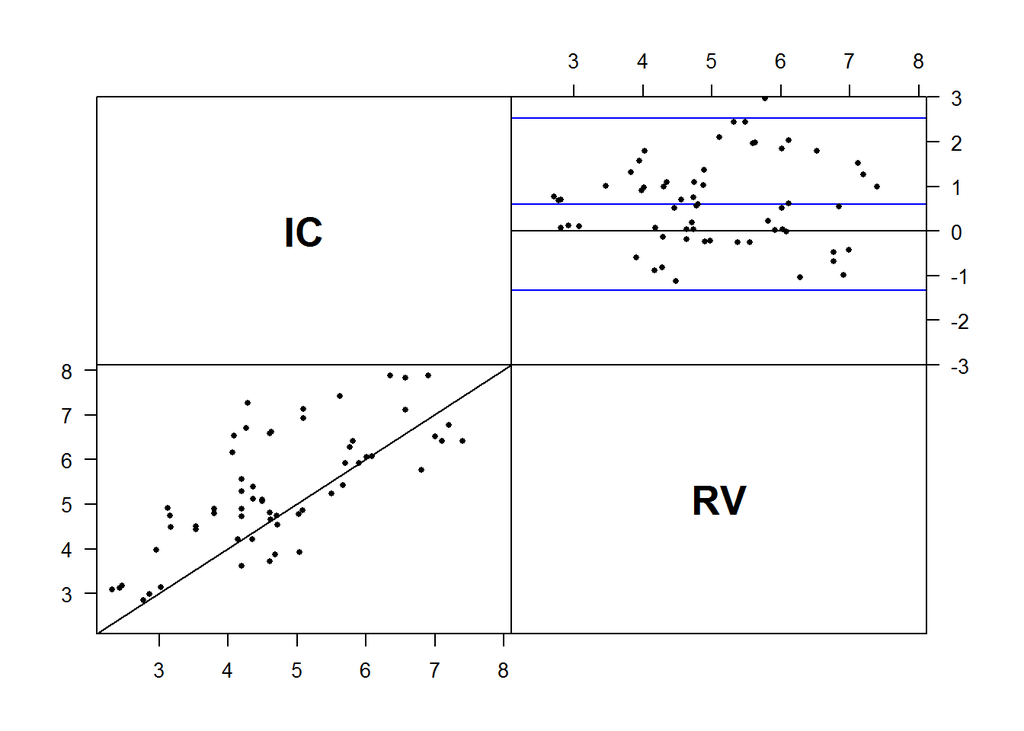

```r
plot(Meth(cardiac))
```

### Between-item Tests

1. Variance Test for Itemwise means

```
## Multiple parameters; naming those columns num.df, denom.df
```

```
## # A tibble: 1 x 9
##   estimate `num df` `denom df` statistic p.value conf.low conf.high method
##      <dbl>    <int>      <int>     <dbl>   <dbl>    <dbl>     <dbl> <chr>
## 1    0.893       11         11     0.893   0.855    0.257      3.10 F tes~
## # ... with 1 more variable: alternative <chr>
```

```r
t.test(y ~ meth,data=cardiac)
```

```
##
##  Welch Two Sample t-test
##
## data:  y by meth
## t = -2.5118, df = 117.89, p-value = 0.01336
## alternative hypothesis: true difference in means is not equal to 0
## 95 percent confidence interval:
##  -1.0769040 -0.1274293
## sample estimates:
## mean in group IC mean in group RV
##         4.721833         5.324000
```

### Roy’s Tests

```r
cardiac.roy1 <- lme(y ~ meth-1, data = dat,
  random = list(item=pdSymm(~ meth-1)),
  weights=varIdent(form=~1|meth),
  correlation = corSymm(form=~1 | item/repl),
  method="ML")
```

```r
cardiac.roy2 <- lme(y ~ meth-1, data = dat,
  random = list(item=pdCompSymm(~ meth-1)),
  correlation = corSymm(form=~1 | item/repl),
  method="ML")
```

```r
cardiac.roy3 <- lme(y ~ meth-1, data = dat,
  random = list(item=pdSymm(~ meth-1)),
  weights=varIdent(form=~1|meth),
  correlation = corCompSymm(form=~1 | item/repl), method="ML")
```

```r
cardiac.roy4 <- lme(y ~ meth-1, data = dat,
  random = list(item=pdCompSymm(~ meth-1)),
  correlation = corCompSymm(form=~1 | item/repl),
  method="ML")
```

## Analysis using BXC

```r
cardiac.bxc1 = lme( y ~ meth + item, random = list( item = pdIdent( ~ meth-1 ) ),
weights = varIdent( form = ~1 | meth ), data=dat)
cardiac.bxc2 = lme( y ~ meth + item, random=list( item = pdIdent( ~ meth-1 ), repl = ~1 ),
weights = varIdent( form = ~1 | meth ), data=dat )
cardiac.bxc3 = lme( y ~ meth + item, random=list( item = pdIdent( ~ meth-1 ), repl = ~1 ),
weights = varIdent( form = ~1 | meth ),
correlation = corCompSymm(form=~1 | item/repl ),data=dat)
```

### Details

It is not entirely clear from the source whether the replicates are exchangeable within (method,item) or whether they represent pairs of measurements. From the description it looks as if replicates are linked between methods, but in the paper they are treated as if they were not.

### Source

- The dataset is adapted from table 4 in: JM Bland and DG Altman: Measuring agreement in method comparison studies. Statistical Methods in Medical Research, 8:136-160, 1999.
- Originally supplied to Bland & Altman by Dr LS Bowling, see: Bowling LS, Sageman WS, O’Connor SM, Cole R, Amundson DE.
- Lack of agreement between measurement of ejection fraction by impedance cardiography versus radionuclide ventriculography. Critical Care Medicine 1993; 21: 1523-27.